# Localised climate change defines ant communities in human‐modified tropical landscapes - Boyle - - Functional Ecology - Wiley Online Library

RESEARCH ARTICLE

Open Access

# Localised climate change defines ant communities in human‐modified tropical landscapes

[Michael J. W. Boyle](https://besjournals.onlinelibrary.wiley.com/action/doSearch?ContribAuthorStored=Boyle%2C+Michael+J+W)

[Tom R. Bishop](https://besjournals.onlinelibrary.wiley.com/action/doSearch?ContribAuthorStored=Bishop%2C+Tom+R)

[Sarah H. Luke](https://besjournals.onlinelibrary.wiley.com/action/doSearch?ContribAuthorStored=Luke%2C+Sarah+H)

[Michiel van Breugel](https://besjournals.onlinelibrary.wiley.com/action/doSearch?ContribAuthorStored=Breugel%2C+Michiel)

[Theodore A. Evans](https://besjournals.onlinelibrary.wiley.com/action/doSearch?ContribAuthorStored=Evans%2C+Theodore+A)

[Marion Pfeifer](https://besjournals.onlinelibrary.wiley.com/action/doSearch?ContribAuthorStored=Pfeifer%2C+Marion)

[Tom M. Fayle](https://besjournals.onlinelibrary.wiley.com/action/doSearch?ContribAuthorStored=Fayle%2C+Tom+M)

[Stephen R. Hardwick](https://besjournals.onlinelibrary.wiley.com/action/doSearch?ContribAuthorStored=Hardwick%2C+Stephen+R)

[Rachel Isolde Lane‐Shaw](https://besjournals.onlinelibrary.wiley.com/action/doSearch?ContribAuthorStored=Lane-Shaw%2C+Rachel+Isolde)

First published: 07 December 2020

https://doi.org/10.1111/1365-2435.13737

[The copyright line for this article was changed on 21 January 2021 after original online publication]

## Abstract

1. Logging and habitat conversion create hotter microclimates in tropical forest landscapes, representing a powerful form of localised anthropogenic climate change. It is widely believed that these emergent conditions are responsible for driving changes in communities of organisms found in modified tropical forests, although the empirical evidence base for this is lacking.
2. Here we investigated how interactions between the physiological traits of genera and the environmental temperatures they experience lead to functional and compositional changes in communities of ants, a key organism in tropical forest ecosystems.
3. We found that the abundance and activity of ant genera along a gradient of forest disturbance in Sabah, Malaysian Borneo, was defined by an interaction between their thermal tolerance (CT<sub>max</sub>) and environmental temperature. In more disturbed, warmer habitats, genera with high CT<sub>max</sub> had increased relative abundance and functional activity, and those with low CT<sub>max</sub> had decreased relative abundance and functional activity.
4. This interaction determined abundance changes between primary and logged forest that differed in daily maximum temperature by a modest 1.1°C, and strengthened as the change in microclimate increased with disturbance. Between habitats that differed by 5.6°C (primary forest to oil palm) and 4.5°C (logged forest to oil palm), a 1°C difference in CT<sub>max</sub> among genera led to a 23% and 16% change in relative abundance, and a 22% and 17% difference in functional activity. CT<sub>max</sub> was negatively correlated with body size and trophic position, with ants becoming significantly smaller and less predatory as microclimate temperatures increased.
5. Our results provide evidence to support the widely held, but never directly tested, assumption that physiological tolerances underpin the influence of disturbance‐induced microclimate change on the abundance and function of invertebrates in tropical landscapes.

A free [Plain Language Summary](http://onlinelibrary.wiley.com/doi/10.1111/1365-2435.13737/suppinfo) can be found within the Supporting Information of this article.

## 1 INTRODUCTION

Elevated temperatures arising because of climate change are expected to have adverse effects on tropical ectotherms (Corlett, 2012; Deutsch et al., 2008; Janion‐Scheepers et al., 2018). At the same time, logging and habitat conversion can significantly alter local microclimates in tropical landscapes (Senior et al., 2017). These disturbance‐related temperature increases are comparable to those expected under global climate warming scenarios for the period 2061–2080 in some tropical forests (Scriven et al., 2015), but may differ in their impacts because changes are felt as soon as the trees are removed, rather than over a time period of decades. Such modification of microclimates therefore represents a potent form of localised climate change that could have powerful impacts on rainforest organisms and the functions they perform (Nowakowski et al., 2018; Scheffers et al., 2014; Tuff et al., 2016; Walther, 2010). Understanding localised climate change effects on ectotherm communities is therefore fundamental in gauging the resilience of tropical forests to global change (Duffy et al., 2015; Tuff et al., 2016).

In Malaysian Borneo it is estimated that around 80% of the total land surface was affected by high‐impact logging or clearance between 1990 and 2009 (Bryan et al., 2013), and 35.1% of land on Borneo was deforested completely between 1973 and 2010 (Gaveau et al., 2014). Logging, fragmentation and conversion of tropical forest to agriculture modifies microclimates, generating hotter, drier and less stable conditions than in primary forest (Blonder et al., 2018; Ewers & Banks‐Leite, 2013; Hardwick et al., 2015). In pristine forests, plant canopies intercept solar radiation before it reaches the ground and leaf transpiration helps keep the air moist, buffering the environment below and creating cool, dark and humid conditions that are fairly homogenous (De Frenne et al., 2019; Hardwick et al., 2015; Pfeifer et al., 2019). Logging removes large trees, thereby reducing the density of leaves, and creating gaps in the canopy (Pfeifer et al., 2015, 2016), leading to locally hotter and drier environments (Hardwick et al., 2015). Conversion of forest to agricultural use, such as oil palm plantation, further amplifies this effect. For example in Borneo, the highest daytime temperatures are on average 1–2°C hotter in logged forest and 5–6°C hotter in oil palm than in primary forest (Hardwick et al., 2015). There is evidence to suggest that microclimates in Bornean tropical forests can return to pre‐logging conditions after 5–10 years owing to forest recovery (Senior et al., 2018). However, these findings are from forests that had undergone lower levels of disturbance than the regional average (Fisher et al., 2011), and the same effect has not been found in more disturbed forests from the same region over similar periods of forest recovery (Blonder et al., 2018).

One of the most functionally important groups of organisms in rainforests are invertebrates (Ewers et al., 2015), which exhibit strong responses to habitat modification (Fayle et al., 2010). Microclimate change has long been implicated as a driving force behind patterns of invertebrate community change from undisturbed to logged and fragmented forests (Didham et al., 2011; Fayle et al., 2010; Gray et al., 2018; Howden & Nealis, 1975). However, to our knowledge, a direct link between microclimate change and shifts in invertebrate community composition along a gradient of disturbance has not been demonstrated empirically. This is highlighted by several reviews examining the traits of species that determine their susceptibility to habitat change. Such reviews routinely identify species‐specific life‐history characteristics such as dispersal ability, rarity and ecological specialisation, but none have invoked the interaction between species' thermal tolerance and microclimate as a key determinant of species' sensitivity (Barnes et al., 2017; Ewers & Didham, 2005; Henle et al., 2004; Ries et al., 2004). Thus, there is a large discrepancy between the widely held assumption that variation among species in their thermal tolerance underpins observed changes in the abundance of invertebrates after land‐use change, and the empirical knowledge base to support this. Testing this assumption requires a clear link to be established between invertebrate physiology, the degree of microclimate change that occurs following disturbance and the relative magnitude of the abundance changes exhibited by organisms that vary in their physiological constraints (Jucker et al., 2020; Tuff et al., 2016).

Ants are a particularly important invertebrate group (Griffiths et al., 2018) and dominate tropical forests in terms of numbers and biomass (Folgarait, 1998; Hölldobler & Wilson, 1990). They are strongly impacted by habitat disturbance in tropical landscapes, with shifts in species composition and reductions in activity following logging, fragmentation and conversion to agriculture (Andersen, 2018; Brühl et al., 2003; Castro Solar et al., 2016; Ewers et al., 2015; Luke et al., 2014), making them ideal study organisms for examining the effects of climate and land‐use change (Andersen, 2018; Baudier et al., 2018). The physiological performance of ants, as small‐bodied ectotherms, can be directly influenced by environmental temperature (Angilletta, 2009). Having evolved in narrow thermal niches, species from tropical regions are expected to be highly susceptible to temperature change (Deutsch et al., 2008; Payne & Smith, 2017), especially those from lowland aseasonal forests (Baudier et al., 2018). Microclimate temperature is therefore likely to exert a strong influence on ant communities by affecting ecological processes such as foraging (Bishop, 2017; Cerda et al., 1998; Jayatilaka et al., 2011; Ruano et al., 2000) and by altering competition and dominance hierarchies (Andersen, 2018; Bestelmeyer, 2008; Cerda et al., 1998; Diamond et al., 2017). While interactions between physiological traits and climatic gradients are well established (Wong et al., 2018), and have been shown to shape invertebrate communities across latitudinal gradients (Diamond & Chick, 2018), altitudinal gradients (Bishop et al., 2017; Montejo‐Kovacevich et al., 2020) and vertical gradients between ground and canopy (Kaspari et al., 2015), this link is yet to be demonstrated across a habitat disturbance gradient in human‐modified tropical landscapes.

Here, we studied ground‐dwelling ants in Malaysian Borneo, examining communities in three habitat types that varied in disturbance: primary forest, logged forest and oil palm plantation. We measured critical thermal maximum, CT<sub>max</sub>—an ecologically relevant physiological trait that represents the maximum temperature at which an organism can function (Duffy et al., 2015; Huey et al., 2012)—of 50 ant genera under laboratory conditions. We mapped this trait onto existing field‐derived datasets of ant abundance and activity at baits within the three habitat types and analysed these data against microclimate temperature recordings from the same locations. We hypothesised that differences in the abundances and activity of ant genera among the three habitat types would be explained by an interaction between thermal conditions at local sampling points and the physiological tolerances of the genera. Specifically, we predicted that ants with high thermal tolerances would have higher abundance and increased functional activity in modified, hotter habitats than in unmodified, cooler habitats; and conversely that ants with low thermal tolerance would have lower abundance and decreased functional activity in modified, hotter habitats than in unmodified, cooler habitats.

## 2 MATERIALS AND METHODS

### 2.1 Sites

All data collection was carried out at Stability of Altered Forest Ecosystems (SAFE) Project sites in Sabah, Malaysian Borneo (Ewers et al., 2011). Within the SAFE Project landscape, sampling points fall within primary dipterocarp rainforest at Maliau Basin Conservation Area, logged rainforest within the Kalabakan Forest Reserve, and oil palm plantation managed by Benta Wawasan and Sabah Softwoods. At the time of sampling, logged forest points were within tracts of continuous forest (over one million hectares). Logged forest sites had been logged once in the mid‐1970s, followed by one to two further rounds of logging between 1990 and 2008 (Ewers et al., 2015; Struebig et al., 2013). A cumulative total of between 150 and 179 m<sup>3</sup> of timber per hectare was removed over these rounds of extraction (Ewers et al., 2015; Struebig et al., 2013), as compared to the average 152 m<sup>3</sup> per hectare across Sabah (Fisher et al., 2011). As such, these forests represent some of the more heavily disturbed logged forests in the region. Oil palm sampling points were in an *Elaeis guineensis* monoculture that was established in the year 2000 and were located at least 1 km away from any forest (Figure 1).

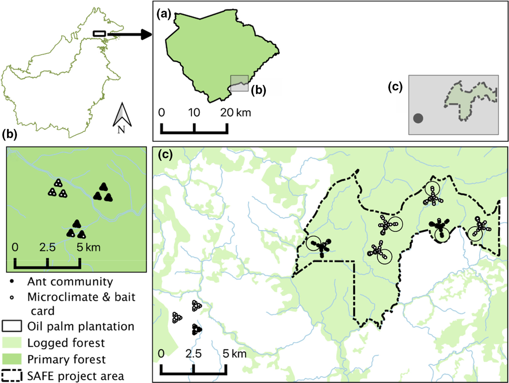

**FIGURE 1**

Map of the SAFE project landscape showing (a) the relative locations of (b) and (c) in Sabah, Malaysian Borneo. (b) Spatial arrangement of sampling points within primary forest control sites at Maliau Basin Conservation Area. (c) Spatial arrangement of logged forest sampling points within the Kalabakan Forest Reserve and oil palm sampling points within the Benta Wawasan plantation. Points displayed are second order sampling points that are separated by 178 m and surrounded by three first order sampling points that are separated by 56 m (see Figure S2). Microclimate and ant bait card data were collected at first order sampling points surrounding all second order points across all sampling blocks. Ant community data were collected at a subset of second order sampling points (*n* = 57, filled circles)

Primary sites were typical of climax community tropical rainforest, with an open understorey, mean ground vegetation (>1 m height) cover of 2% and mean litter depth of 2.3 cm. Logged sites were characterised by a very dense understorey, mean ground vegetation cover of 2% and mean litter depth of 2.0 cm. Oil palm sites were typically very open with little to no understorey or litter layer, but with mean ground vegetation cover of 19%.

Sampling points were part of the SAFE Project sampling set‐up and were clustered in 12 blocks, with 3 in primary forest, 6 in logged forest and 3 in oil palm (Figure 1). Blocks contained either 9 (primary forest and oil palm) or 16 (logged forest) ‘second order’ sampling points each separated by 178 m. Around each of these sampling points were clustered a further three ‘first order’ sampling points separated by 56 m (Figure S1; see Ewers et al., 2011 for full SAFE Project sampling set‐up). Data were collated from existing, independently collected datasets. This was facilitated by the nested structure of the SAFE Project sampling design, with microclimate and ant activity collected across all 12 sampling blocks (3 primary, 6 logged, 3 oil palm), and ant community composition collected from a subset of 5 of the sampling blocks (2 primary, 2 logged, 1 oil palm). Microclimate (*n* = 244) and ant activity (*n* = 264) data had been collected at ‘first order’ sampling points, of which 133 points overlapped. Ant community data (*n* = 57) had been collected at ‘second order’ sampling points and were not directly analysed against microclimate data. We expected that the distance between points would be far enough apart to prevent workers moving between points when foraging (Byrne, 1994; Sorvari, 2009). Any observed differences between communities at different points would therefore likely be due to the ability of a genus to persist at any given point. We also expected microclimate data points would be independent beyond a distance of 20–30 m (Didham & Lawton, 1999; Ewers & Banks‐Leite, 2013).

Climate at our study site has low interannual variation and is aseasonal, with no distinct wet and dry season to be accounted for in our sampling (Walsh & Newbery, 1999). There were also no ENSO‐related weather events during any of the data collection periods, meaning that microclimate, ant community and activity data from different years within our sampling period could be compared. The elevation of sampling points at the SAFE project is standardised across sampling blocks, with a mean elevation of 450 m and an interquartile range between sampling points of 72 m.

### 2.2 Microclimate measurements

We took microclimate measurements at 244 ‘first order’ sampling points (primary = 47, logged = 142, oil palm = 55) within all 12 blocks (Figure 1). Ambient air temperature was assessed between September 2011 and April 2013 using Hygrochron iButtons suspended in shade at a height of 1.5 m above ground at each first order sampling point (see Hardwick et al., 2015 for details). Sensors were shaded by vegetation only. A subset of sensors were paired with sensors shaded by full radiation shielding over a range of canopy openness to test for measurement bias arising from a reliance on vegetation shading. Paired sensors exhibited a mean variation of <0.5°C over a trial period of 45 days (Hardwick, 2015).

Sensors were set to record temperature every 3 hr. To ensure there was comparability among data and to enable us to use data from as many sampling points as possible, we randomly selected 100 individual days from across those available per point from the entire sampling period. Mean maximum daily temperature was 5.6°C greater in oil palm (31.5°C) than in primary forest (25.9°C) and 1.1°C greater in logged forest (27°C) than in primary forest (Figure 2).

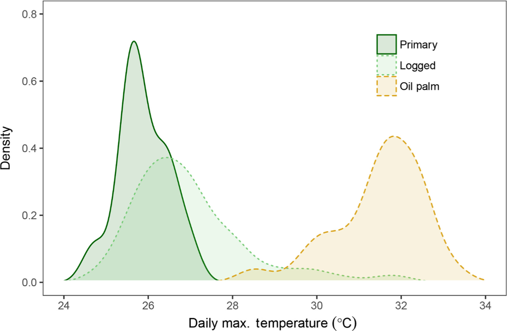

**FIGURE 2**

Smoothed kernel densities of maximum daily temperature from 244 individual sampling points across three different habitat types. Recordings were collated from 100 randomly selected days for each sampling point between September 2011 and April 2013. Average maximum daily temperature varied by 5.6°C across the three land‐use types, from a low of 25.9°C in primary forest to a high of 31.5°C in oil palm plantation. Maximum daily temperatures were on average 1.1°C hotter in logged than in primary forest

### 2.3 Assessing thermal tolerance

Live ants were collected opportunistically between February 2015 and July 2016 from 39 second order sampling points (primary = 18, logged = 12, oil palm = 9) within seven sampling blocks. These overlapped with four of the five ant community sampling blocks. Ants were found by manual searching through leaf litter, dead wood and understorey vegetation, or attracted by baiting with a mixture of tuna, cat food and honey both on the soil surface using bait cards, and in the soil using buried plastic test tubes with holes drilled in the sides. Collected ants were immediately transported to the laboratory to assess thermal tolerance. When ants had to be transported from more distant sites, they were kept in an insulated cool box containing some leaf litter and small twigs. Time between collection and experiments was no longer than 3 hr (mean = 1.27 hr).

Thermal tolerance was assessed using a ramping procedure to determine CT<sub>max</sub> (Bishop et al., 2017; Kaspari et al., 2015; Terblanche et al., 2011). Ants were placed into individual glass vials and submerged in a water bath (Grant Instruments TFX200) set to 32°C. After a 5‐min period to allow the air in the vials to match the temperature of the water, temperature was ramped upwards at a rate of 0.2°C per minute. After every increase of 2°C ramping was paused for 2 min to make certain of equilibrium between vial and water temperature. We chose 32°C because this was the mean daytime temperature of the laboratory. We used 0.2°C per minute because it is a commonly used ramping speed (Guo et al., 2020) and was the fastest ramping speed that maintained equilibrium between the water and the air within the vials (measured with a thermocouple placed within a randomly selected vial during calibration runs). CT<sub>max</sub> was defined as the temperature at which individuals lost complete motor control, the assumption being that inability to move represents ecological death. After the trials, ants were identified to genus level owing to time and resource constraints in the field. We were able to assess the thermal tolerance of 2,359 individual ants from 50 of the 100 genera that are known from Borneo (Table S1).

Ramping procedures may give variable estimates of CT<sub>max</sub> depending on the rate of temperature increase and acclimation times in the laboratory (Santos et al., 2011; Terblanche et al., 2011). These effects are unlikely to have biased our findings as all genera in this study were subject to the same ramping protocol, and we aimed to look at the relative effects of temperature and physiology across genera rather than the absolute effect of temperature on individual genera.

CT<sub>max</sub> of individual workers may give less conservative estimates of thermal tolerance than limits defined strictly from behavioural activities such as foraging (Guo et al., 2020), or from colony growth (Diamond et al., 2013). While colonies may be established at varying depths in the soil, or within twigs and other cavities to maintain ideal temperatures, workers must forage outside the nest to provide energy for the colony. Consequently, any behavioural modification to foraging activity represents a trade‐off where potential energy provided to the colony is lost. In this way, the CT<sub>max</sub> of workers represents the absolute maximum temperature for persistence, as air temperatures exceeding it will preclude continued colony growth and survival. Air temperatures exceeding colony CT<sub>max</sub>, however, do not necessarily preclude foraging (Diamond et al., 2013).

### 2.4 Ant community sampling

Ant community collection was carried out at 57 ‘second order’ points (primary = 16, logged = 32, oil palm = 9 within five sampling blocks) in April and May 2010 (see Luke et al., 2014 for details). At each of the 57 sampling points, a 4 m × 4 m grid was laid out and 16 soil pits (12 cm diameter × 10 cm depth) were dug, one in the centre of each square metre. Soil was removed from each pit and hand‐searched for ants for 10 person‐minutes. Ants were preserved in 70% ethanol and identified to genus using relevant literature (Bihn & Verhaagh, 2007; Bolton, 1994; Brown, 1980; Fayle, 2014; Heterick & Shattuck, 2011; Moffett, 1986; Rigato, 1994; Shattuck, 2011; Shattuck & Barnett, 2007; Taylor, 1985, 1990; Wilson, 1964). Reproductives were excluded from counts to ensure ants were living in the habitat rather than simply passing through. The stratification of ants in forests in Borneo is also very strict, suggesting that the majority of ants sampled at the ground layer are specific to this layer, and not moving down from the canopy to forage (Bruhl et al., 1998). We collected 4,620 ants representing 61 genera from the soil pits.

### 2.5 Ant functional activity

Observations of foraging ants visiting bait cards were carried out at 264 ‘first order’ sampling points (primary = 36, logged = 192, oil palm = 36) within all 12 blocks between June 2011 and December 2011. Small pellets (maximum diameter 3 mm) made of crushed earthworm (Tropical Fish Food Earthworm Pellets: High Protein, [ukfishfood.co.uk](http://ukfishfood.co.uk/)) were placed on bait cards made from laminated graph paper and observed for 40 min, with abundances of each visiting ant species recorded. Voucher specimens were taken of each ant species visiting the card and identified using appropriate keys (see Section 2.4). In total 23,253 individual ants were observed, representing 46 genera.

### 2.6 Body size

The body size of ants from the community sample (mean = 3 individuals per morphospecies) were measured to the nearest 0.01 mm using an ocular micrometer attached to a Leica MS5 stereo‐microscope (Leica Microsystems) and averaged at the genus level. Reproductive forms and major castes were excluded from analyses and so were not measured. We used Weber's length (a diagonal measurement across the mesosoma of an ant) as a surrogate for body size, which is thought to relate to many life‐history traits including individual prey selection (Traniello, 1987) and thermal tolerance (Baudier et al., 2015). It is also correlated with other morphological features known to vary with resource selection (Kaspari, 1996; Weiser & Kaspari, 2006).

### 2.7 Trophic position

We used ratios of stable nitrogen isotopes (δ<sup>15</sup>N), compiled from the literature (Blüthgen et al., 2003; Pfeiffer et al., 2013; Woodcock et al., 2013), to describe the trophic position of each ant genus, with higher values representing high levels of predation and lower values representing species with more herbivorous diets (Davidson et al., 2003). Each data source referred only to ants from forests within Borneo. Each source used baseline‐corrected isotope values from leaf litter and soil to allow for comparison of ants from different areas within the original studies, allowing values to be compiled across studies. The majority of values were averaged at the genus level within Woodcock et al. (2013) and Pfeiffer et al. (2013); only where a genus occurred in both datasets did we take the mean across studies. Data from Woodcock et al. (2013) were averaged from both habitats represented in the study (primary forest and logged forest). Data were not available from these studies for two genera in our analysis, so we used data published by Blüthgen et al., 2003, where isotope ratios were derived from canopy ants (Table S1).

### 2.8 Statistical analysis

All analyses were carried out in R version 3.4.1 (R Development Core Team, 2018). Across all analyses, we used maximum daily temperature, as average temperatures can obscure variation in temperature at sites (Dillon et al., 2010), and high temperatures are expected to exert the strongest filtering effects on insect communities (Kingsolver et al., 2011). To facilitate the comparison of information from multiple datasets and sources, we carried out all analyses at the genus level, which was the lowest taxonomic level represented in all datasets. Not all genera were represented in all datasets, meaning individual analyses contained variable numbers of genera. A full list of the ant genera contained in each of the separate datasets and analyses can be found in Table S1.

This genus‐level approach allowed us to combine disparate datasets, and improved spatial coverage of ants across the disturbance gradient in our study. Physiological, functional and behavioural traits are biologically meaningful at the generic level in ants (Andersen, 1995, 1997; Guo et al., 2020) and global studies comparing the thermal physiology of ants have been carried out at the genus level (Guo et al., 2020). A caveat of this approach is that it may introduce noise, as some diverse genera may include species with varying thermal tolerance. It is also possible that rare genera may be represented by single species in our datasets, thereby not representing the full range of potential CT<sub>max</sub> values for those genera. These potential issues are unlikely to bias our results, as the majority of abundant and speciose genera are well represented by large numbers of individuals from many locations, and we expect that a species‐level analysis would only strengthen any observed effects by explaining more variation in the data.

For each of the 23 genera from the ant community sample represented in our phylogeny, we calculated the relative abundance of individuals within each habitat type and quantified the percentage change in abundance between each of the three land‐use types (primary vs. logged forest; primary forest vs. oil palm; logged forest vs. oil palm). We ran phylogenetic least squares regressions (PGLS) using the package Caper (Orme et al., 2013) to test whether genus‐specific changes in relative abundance between each land‐use type were correlated with CT<sub>max</sub>, while controlling for phylogenetic non‐independence of genera.

We then repeated this analysis using ant functional activity data to test whether any observed changes in the abundance of ants in our community data were reflected in the ants found foraging at bait cards on the surface. Due to potential bias from dominant ants recruiting to baits in high numbers, we used genus incidence data for analyses of ant activity. We calculated the proportion of bait cards visited by each of the 23 genera of ants within each habitat (primary = *x*/36, logged = *x*/192, oil palm = *x*/36), and used PGLS to test whether the percentage change in presence at bait cards between each habitat type was correlated with CT<sub>max</sub>. Across all samples, the community and activity datasets had 88.5% overlap of ant genera (Table S1).

To determine whether these genus‐level changes translated into a detectable change in the overall thermal tolerance of ants, we calculated the community mean CT<sub>max</sub> at each of the 133 ‘first order’ sampling points where microclimate and ant activity data overlapped. We used 26 genera for which we had both CT<sub>max</sub> and activity data and calculated community CT<sub>max</sub> based on the incidence of genera at bait cards. Together, these 26 genera comprised 88.3% of the total number of individuals from the ant activity observations. We used LMER, defining sampling block as a random effect, and Tukey's post hoc tests to test whether changes in community‐level thermal tolerance were detectable among habitat types. We also repeated this analysis at the scale of individual sampling points, again using LMER to quantify the strength of the relationship between community‐level thermal tolerance and microclimate temperature while accounting for repeated measures from multiple sampling blocks.

Finally, we used linear regression to correlate body size (*n* = 26 genera) and trophic position using nitrogen stable isotope ratios (*n* = 31 genera) with CT<sub>max</sub> to understand how any observed interactions between microclimate and physiology might directly impact the ecological functions mediated by the ant community.

## 3 RESULTS

CT<sub>max</sub> varied significantly among genera (Figure 3; ANOVA: *F*<sub>49,2,193</sub> = 135.4, *p* < 0.001, *R*<sup>2</sup> = 0.75), ranging from the lowest value in the genus *Leptogenys* (40°C, *SE* = 0.14) to the highest in *Ochetellus* (47°C, *SE* = 0.4). Variance component analysis showed that 80.2% of variation in CT<sub>max</sub> was held among genera, with just 19.8% held within genera. There was significant phylogenetic signal observed in CT<sub>max</sub> using both Pagel's *λ* (*λ* = 1, *p* = 0.02) and Blomberg's *K* (*K* = 1.19, *p* = 0.004).

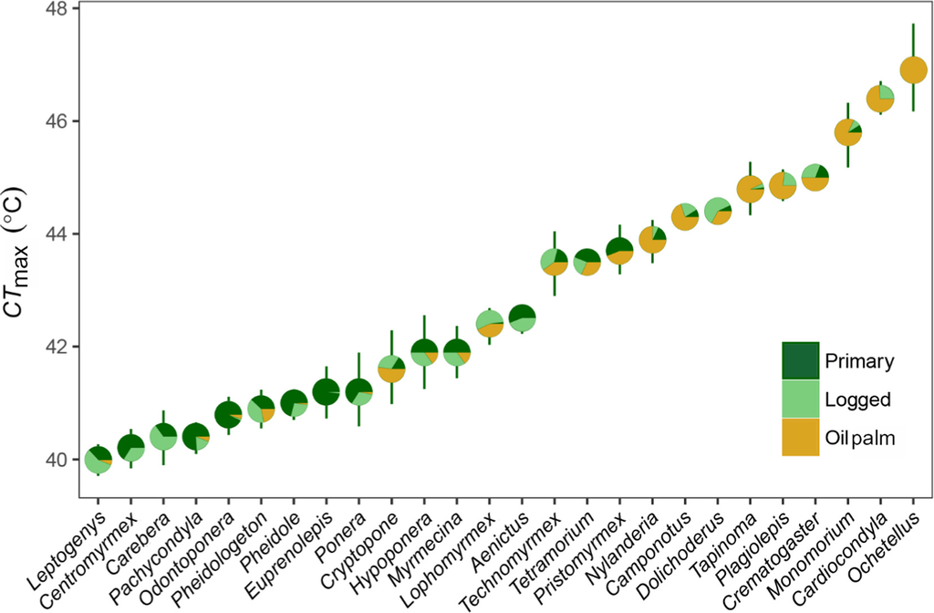

**FIGURE 3**

Variation in the thermal tolerance of 26 tropical ant genera for which we also collected data on their relative abundance from community sampling in primary forest, logged forest and oil palm plantations. Thermal tolerance is quantified as the upper critical temperature, CT<sub>max</sub> (°C, ±95% confidence interval). Genera are ordered according to CT<sub>max</sub>. Pie charts are centred on the mean CT<sub>max</sub> for each genus, and show the proportional distribution of that genus among primary forest, logged forest and oil palm habitats. Between them, these 26 genera represent more than 80% of the ant individuals in the community

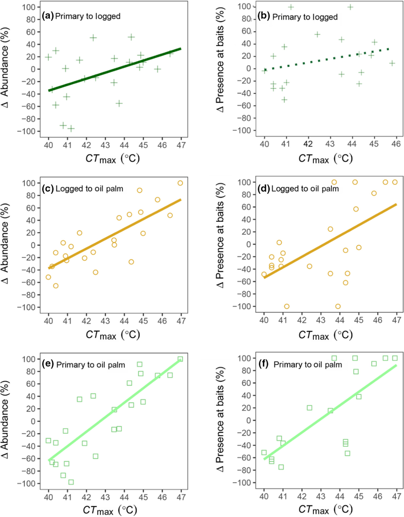

**FIGURE 4**

Change in the abundance of tropical ant genera from community samples and their functional activity at bait cards across a land‐use gradient as a function of their thermal tolerance (CT<sub>max</sub>). Three habitat transitions are represented: primary to logged forest (a) *n* = 22, *p* = 0.03, slope = 9.7, *R*<sup>2</sup> = 0.21; (b) *n* = 19, *p* = 0.1, slope = 7, *R*<sup>2</sup> = 0.1; logged forest to oil palm plantation (c) *n* = 23, *p* < 0.001, slope = 15.9, *R*<sup>2</sup> = 0.62; (d) *n* = 23, *p* < 0.001, slope = 17, *R*<sup>2</sup> = 0.4; and primary forest to oil palm plantation (e) *n* = 23, *p* < 0.001, slope = 23.3, *R*<sup>2</sup> = 0.68; (f) *n* = 19, *p* < 0.001, slope = 21.7, *R*<sup>2</sup> = 0.62. Each data point is a genus. Abundance changes are represented as changes in the relative abundance of individuals within genera between each habitat. Changes in functional activity are represented as the change in proportion of bait cards within habitats at which the genus was present. Negative values indicate genera that decreased in abundance or presence, and positive values indicate genera that increased in abundance or presence. Fitted lines are from phylogenetically informed least squares regression

Thermal tolerance also explained changes in the functional activity of ants between both forest types and oil palm (Figure 4d; logged forest to oil palm; PGLS: *F*<sub>1,22</sub> = 15, *p* < 0.001, *SE* = 4.5, *R*<sup>2</sup> = 0.4. Figure 4f; primary forest to oil palm; PGLS: *F*<sub>1,17</sub> = 28, *p* < 0.001, *SE* = 4.1, *R*<sup>2</sup> = 0.62), where a 1°C difference in CT<sub>max</sub> corresponded to a 16.9% and a 21.7% difference in the proportion of baits visited respectively. Changes between primary forest and logged forest also showed a positive, albeit non‐significant, trend between CT<sub>max</sub> and activity rate (Figure 4b; primary forest to logged forest; PGLS: *F*<sub>1,17</sub> = 1.8, *p* = 0.1, *SE* = 5.2, *R*<sup>2</sup> = 0.1).

We found significant differences in community mean CT<sub>max</sub> of ants active at baits between primary forest and both modified habitat types (Figure 5a; LMER: *F*<sub>2,259</sub> = 37.4, *R*<sup>2</sup> = 0.24, logged forest: *p* < 0.01, oil palm: *p* < 0.0001). This was explained by the increasing temperature at sampling points within those habitats, where a 1°C increase in maximum daily temperature corresponded to a 0.2°C increase in community CT<sub>max</sub> (Figure 5b; LMER: *F*<sub>1,131</sub> = 33.32, *SE* = 0.07, *p* < 0.001, *R*<sup>2</sup> = 0.23).

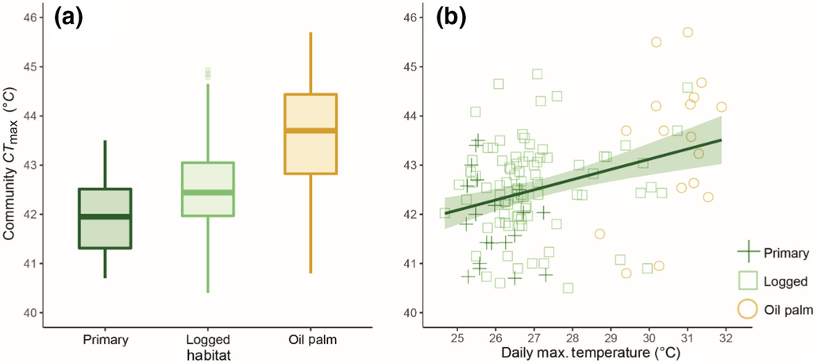

**FIGURE 5**

Trophic position was significantly correlated with CT<sub>max</sub>, with ants becoming less predatory and more herbivorous as thermal tolerance increased (Figure 6a; LM: *F*<sub>1,29</sub> = 13.7, slope = −0.45, *p* < 0.001, *SE* = 0.12, *R*<sup>2</sup> = 0.32). CT<sub>max</sub> was negatively correlated with body size, with ants becoming smaller as CT<sub>max</sub> increased (Figure 6b; LM: *F*<sub>1,24</sub> = 7, slope = −0.12, *p* < 0.01, *SE* = −0.05, *R*<sup>2</sup> = 0.22).

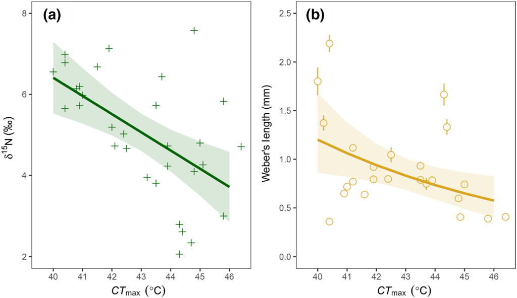

**FIGURE 6**

(a) δ<sup>15</sup>N as a function of CT<sub>max</sub>. δ<sup>15</sup>N decreases steadily as CT<sub>max</sub> increases across 31 genera of ants, from 6.4‰ at the lowest values of CT<sub>max</sub> to 3.7‰ at the highest values of CT<sub>max</sub> (*n* = 31, *p* < 0.001, slope = −0.45, 95% CI = 0.12, *R*<sup>2</sup> = 0.32). δ<sup>15</sup>N is a measure of trophic position, with higher values indicating a more carnivorous diet and lower values indicating a more herbivorous diet. Crosses represent individual genera, the line is from linear regression and the shaded polygon represents the 95% confidence interval. (b) Weber's length (mm) as a function of CT<sub>max</sub>. Weber's length (a diagonal measurement across the mesosoma of an ant used as a reflection of body size) decreased as CT<sub>max</sub> increased across 26 genera of ants, from 1.3 mm at the lowest values of CT<sub>max</sub> to 0.6 mm at the highest values of CT<sub>max</sub> (*n* = 26, *p* < 0.01, slope = −0.12, 95% CI = 0.05, *R*<sup>2</sup> = 0.22). Circles represent individual genera with error bars representing standard error around the mean Weber's length (mm). The fitted line is from linear regression, and the shaded polygon represents the 95% confidence interval

## 4 DISCUSSION

We found that interactions between microclimate and physiology are significantly related to changes in the abundance, functional activity, trophic level, body size and community composition of ants. To our knowledge, this is the first study that combines measures of invertebrate physiology with observations of activity, community structure, functional traits and environmental measurements in disturbed tropical forests. We present compelling evidence of a mechanistic link between localised climate change effects and the abundance and functioning of tropical invertebrate communities. Changes to the structure of functionally important communities such as ants can have cascading impacts on ecosystem‐level properties (Balvanera et al., 2006; Hooper et al., 2005), so understanding the direct impacts of disturbance‐induced microclimate change on their community composition and function in tropical systems is a research priority.

We sampled ant communities from the soil (for assessing abundance) and observed ants foraging on the surface (for assessing activity), and demonstrated a similar effect of temperature and physiology on the abundance and activity of ants from both microhabitats. Life history and nesting characteristics have been shown to influence the CT<sub>max</sub> of tropical forests insects (Baudier et al., 2015; Kaspari et al., 2015; Woon et al., 2018), with specialised soil ants having lower thermal tolerances than surface foraging ants (Baudier et al., 2015). The soil in tropical forests can increase in temperature more dramatically than the air following logging (Lal & Cummings, 1979; Yashiro et al., 2008), and the combination of these factors may explain why a significant effect of temperature between primary and logged forest was observed in the case of the soil ant community, but not for the surface foraging community. The elevated temperatures recorded after conversion to oil palm, however, were strong enough to powerfully influence the characteristics of both communities.

Changes in the abundance of certain insect groups after habitat disturbance can also be linked to their level of specialisation, such as how closely linked they are to a certain host, prey or habitat type (Didham et al., 1996). The ants in our study mostly nest in the soil or leaf litter layer, and leaf litter characteristics have been shown to be important determinants of ant community composition (Kaspari, 1996). At our sites, understorey plant cover and leaf litter depth were the same between primary and logged forest, suggesting that direct effects of disturbance on habitat characteristics should not strongly influence these communities (Andersen, 2018; Didham et al., 1996). Furthermore, community CT<sub>max</sub> effects were significant even when oil palm sites were excluded from the analysis, suggesting that localised climate change effects following disturbance are a defining factor shaping ant communities at these sites.

In our analysis, the same 1°C change in temperature had different effect sizes between different habitat types. This was true for both the magnitude of abundance change and activity at baits. This could be explained by the exponential effect of temperature on biological rates (Payne & Smith, 2017). Biological rates proceed increasingly rapidly at higher temperatures, meaning that a 1°C change at a relatively low temperature is not biologically equivalent to a 1°C change at a higher temperature (Payne & Smith, 2017). Because primary forest and logged forest are both relatively cool in comparison to oil palm, a 1°C change in microclimate could have a much larger biological effect in comparisons involving oil palm than between primary and logged forest types.

Our results show that environmental temperature and community CT<sub>max</sub> do not increase in line with each other and that there is variation in the response between genera with similar CT<sub>max</sub>. There are three possible explanations for this. Firstly, certain ants have been shown to be able to change their behaviour in response to changes in their thermal environment (Andrew et al., 2013), in some cases even switching from diurnal to nocturnal activity patterns (Briese & Macauley, 1977). Ants with low CT<sub>max</sub> but highly plastic life‐history traits may therefore be able to persist in unfavourable thermal conditions through behavioural thermoregulation (Sunday et al., 2014), while other genera with similar thermotolerance but less flexible life‐history traits become locally extinct (Linksvayer & Janssen, 2009). Secondly, it is possible that certain diverse genera contain species with differing CT<sub>max</sub> that we have failed to measure by using a genus‐level approach (Franken et al., 2018). In this case, the abundance of some genera with high intraspecific variation would remain level, while the relative abundances of species within the genus were shifting. We tried to test for intraspecific variation in our data using variance components and showed that 80% of the variation in CT<sub>max</sub> occurred among genera and only 20% within genera. While the most abundant genera were sampled multiple times from multiple locations, it is possible that some rare genera may only be represented by single species in our data. Finally, the CT<sub>max</sub> of workers may not directly reflect the CT<sub>max</sub> of the colony. Most genera in our study nest either in the soil or in twigs and other material in the leaf litter. While colonies rely on foraging workers to provide energy for the nest, CT<sub>max</sub> for colony growth can be up to 8.3°C lower than the CT<sub>max</sub> of individual workers (Diamond et al., 2013). It is possible therefore that ants with more buffered nest locations, but lower individual CT<sub>max</sub>, may persist where ants with higher CT<sub>max</sub> but less buffered nest locations could not.

Across all genera the mean CT<sub>max</sub> was 42.4°C, a temperature that was unlikely to be reached in even the most heavily disturbed habitats in this study (Hardwick et al., 2015). However, air temperatures may not capture the full range of conditions experienced by an ant (Kaspari et al., 2015; Stark et al., 2017). Both surface and air temperatures are significantly linked to canopy openness, with reductions in canopy cover leading to increases in both metrics (Pfeifer et al., 2019). While air and surface temperatures show similar spatial and temporal patterns (Heinl et al., 2015; Janatian et al., 2017), surfaces in tropical forests can reach temperatures significantly higher than those of the surrounding air temperature (Kaspari et al., 2015; Stark et al., 2017), and in disturbed habitats readily reach temperatures approaching or surpassing the CT<sub>max</sub> of ant genera present in our community (Blonder et al., 2018; Mollinari et al., 2019). While some ants have evolved physiological adaptations allowing them to forage close to their CT<sub>max</sub> (Christian & Morton, 1992; Wehner & Wehner, 2011), these are unlikely to have been selected for at the ground layer in tropical forests, as conditions have been relatively cool and stable over long geological time periods (Corlett, 2011).

The effects of temperature increases can be described in terms of direct or indirect effects. Direct effects of temperature may be positive or negative, depending on where an organism currently sits on its thermal performance curve. Indirect effects involve interactions between genera, where small temperature increases may affect comparative fitness and cause shifts in competitive networks (Diamond et al., 2017). Related work in both tropical and boreal forests has demonstrated that ant competitive networks in disturbed habitats have been shuffled relative to undisturbed habitats, with some genera becoming more, and others less, competitive (Gibb, 2011; Gray et al., 2018). In the Neotropics, subordinate heat‐tolerant ants forage at high temperatures during the middle of the day where they have a competitive advantage over more dominant ants with lower thermal tolerance (Jayatilaka et al., 2011). Changes in community structure could therefore be arising because the competitive ability of genera with high CT<sub>max</sub> increases relative to those with low CT<sub>max</sub>, even at sublethal increases of environmental temperature.

Modifications to community structure can affect the ecosystem processes mediated by that community (Ewers et al., 2011). Morphological and physiological traits define the contributions species make to ecosystem processes, as well as their tolerance to disturbance (Díaz et al., 2013; Suding et al., 2008). Our data show that larger, predatory ants with low CT<sub>max</sub> decline in abundance while smaller, more herbivorous ants with high CT<sub>max</sub> increase, a trend that conforms to patterns seen in disturbed habitats both locally (Senior et al., 2013) and globally (Gibb et al., 2018). In our data there is more variation in CT<sub>max</sub> among ants with more carnivorous diets, suggesting that a small proportion of predatory ants may be resilient to elevated temperatures. Complex communities such as tropical rainforests are often regulated by tri‐trophic interactions involving bottom‐up and top‐down forces (Fornoff et al., 2019). Ants play a key role in these interactions in forests by providing a top‐down control on other abundant functional groups such as insect herbivores (Davidson et al., 2003; Floren et al., 2002; Godschalx et al., 2019). This is also important in oil palm plantations, where ants can provide a pest management service by controlling herbivorous insect outbreaks (Turner & Hinsch, 2018). The resilience of this regulatory function could be significantly reduced following microclimate change by reducing the suite of predatory ants, which could lead to reduced yields in plantations (Turner & Hinsch, 2018) and altered successional pathways in forests (Guariguata & Ostertag, 2001).

At this study site, the functional role of invertebrates such as ants is reduced by as much as one half in logged compared to primary forest (Ewers et al., 2015). This result is correlated with functionally important groups such as large‐bodied, predatory ants decreasing in abundance after land‐use change (Ewers et al., 2015). Our results suggest that microclimate change, arising because of changes to the physical structure of the habitat after disturbance, likely underpins these observed changes to community composition and function. This is a finding that has been widely assumed to be proven for some time, albeit in the absence of direct empirical tests (Didham et al., 2011; Fayle et al., 2010; Howden & Nealis, 1975). This study provides the missing empirical support using a simple trait‐based framework. We have also demonstrated that physiological traits such as CT<sub>max</sub> can be phylogenetically structured in this community and correlated with functional traits such as body size and trophic position. This has implications for the resilience of ecosystem processes delivered by ants, and may present opportunities for a mechanistic analysis of the impact of future warming on ecosystem functions (Díaz et al., 2013).

Forests around the world are being rapidly disturbed and fragmented (Haddad et al., 2015), leading to novel landscapes characterised by heavily altered microclimates (Senior et al., 2017). Concurrently, global climate change is likely to be one of the biggest threats to biodiversity in the coming decades (Travis, 2003). Species living in disturbed habitats therefore face the combined challenge of global climate change acting on top of an already elevated thermal environment. In the face of such major and potentially synergistic changes, we urgently need to understand how warmer conditions affect forests and the species that live within them (Cavaleri et al., 2015). Here, we have demonstrated that disturbance‐induced microclimate change at very localised scales has already left its signature on tropical forest communities. The challenge now is to understand how these community‐level changes will ripple throughout ecosystems to influence other organisms, functions and the processes that maintain biodiversity.

## ACKNOWLEDGEMENTS

We thank the Malaysia Economic Planning Unit, Sabah Biodiversity Centre (SABC), Maliau Basin Conservation Area Management Committee (MBMC) and the South East Asia Rainforest Research Partnership (SEARRP) for providing research permission for field work in Sabah and staff for support in the field. The research was carried out under SABC access license number JKM/MBS.1000‐2/2 (198). This study was supported by Sime Darby Foundation funding to the SAFE Project. M.J.W.B. was supported by an ICL‐NUS PhD Scholarship from Imperial College London. S.H.L. was funded by the UK Natural Environment Research Council (NERC), the University of East Anglia and the Sir Philip Reckitt Educational Trust. T.M.F. was supported by a Czech Science Foundation Standard Grant (19‐14620S). E.C.T. was supported by the UK Natural Environment Research Council (NERC; NE/K016377/1). We thank Louise Ashton and Genevieve Finerty for commenting on the manuscript. This paper represents a contribution to Imperial College's Grand Challenges in Ecosystems and the Environment Initiative. The authors state no conflict of interest.

## AUTHORS' CONTRIBUTIONS

M.J.W.B., R.M.E., M.v.B. and T.A.E. designed the study; M.J.W.B. carried out all analyses and wrote the first draft of the manuscript; M.J.W.B., T.R.B., S.H.L., S.R.H., R.I.L.‐S., M.P., T.M.F., K.M.Y., E.C.T., I.C.R.A., O.S.A. and E.G. contributed data; C.L.W. conducted GIS and made map figures; A.Y.C.C. acted as local collaborator and facilitated work in Malaysia. All authors commented on and edited the manuscript.

## REFERENCES

### Details

[figure not shown]